# RNA-seq expression normalisation

Konrad Rudolph ([@klmr](https://twitter.com/klmr))

## RNA-seq gene expression by counts

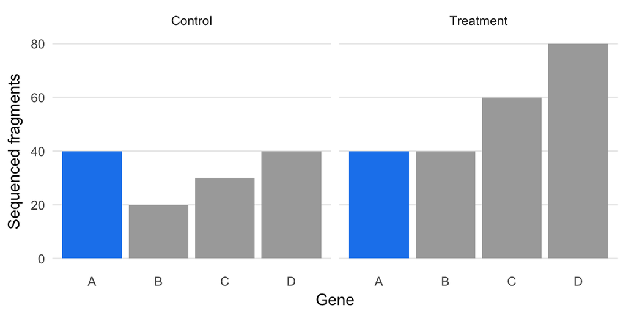

But: we don’t want  
**fragments per library**.

We want  
**RNA molecules per cell**.

## Library size effect

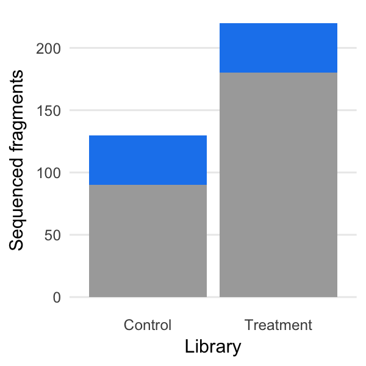

## RNA-seq gene expression as fractions

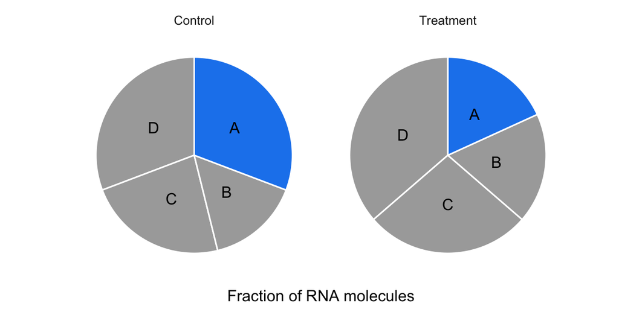

## Sources of variability

- Across libaries
  - Amount of RNA sequenced
  - Technical noise
- Across transcripts
  - … longer transcripts = more fragments
- Biologically meaningful

## Transcript length

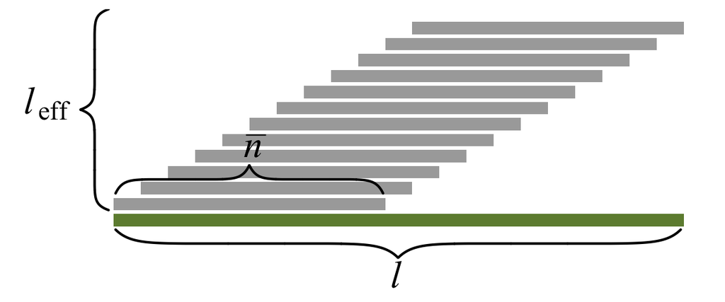

$$\large
l_\text{eff} = l - \bar{n} + 1$$

Different transcript lengths lead to different expected fragment counts

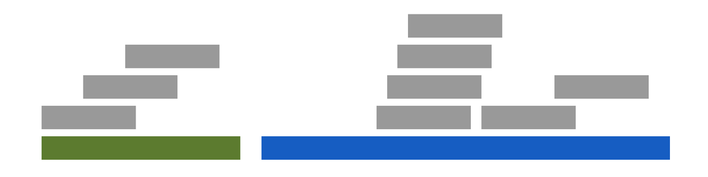

## To review

RNA-seq count is influenced by

- Library size
- Transcript length

> **TPM** (transcripts per millions): Given a million RNA fragments, how many fragments of a given transcript do we see?

→ TPM is a relative *fraction*, not absolute expression

$$\large
\text{TPM}_\color{orchid}i =
{\color{dodgerblue}{\frac{x_\color{orchid}i}{{l_\text{eff}}_\color{orchid}i}}}
\cdot
\frac{1}{\sum_\color{tomato}j \color{dodgerblue}{\frac{x_\color{tomato}j}{{l_\text{eff}}_\color{tomato}j}}}
\cdot
\color{darkcyan}{10^6}$$

- $\color{orchid}i$: transcript index,
- $x_i$: transcript raw count,
- $\color{tomato}j$ iterates over all (known) transcripts,
- $\color{dodgerblue}{\frac{x_k}{{l_\text{eff}}_k}}$: rate of fragment coverage per nucleobase,
- $\color{darkcyan}{10^6}$: scaling factor (= “per millions”).

## RNA-seq gene expression in TPM

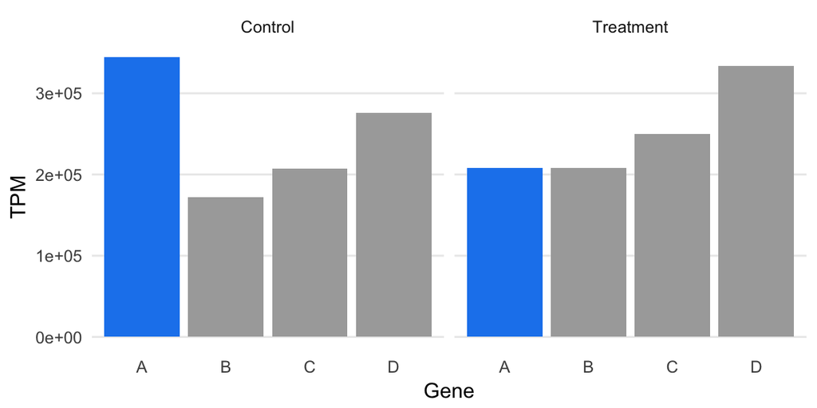

- Differentially expressed transcripts are clearly different
- Identical transcripts are very similar
- But not entirely the same
- 🎗 TPMs are relative fractions of library
- → Comparison across libraries requires additional effort

## Cross-library normalisation

Fundamental assumption:

> Most transcripts are **not** differentially expressed.

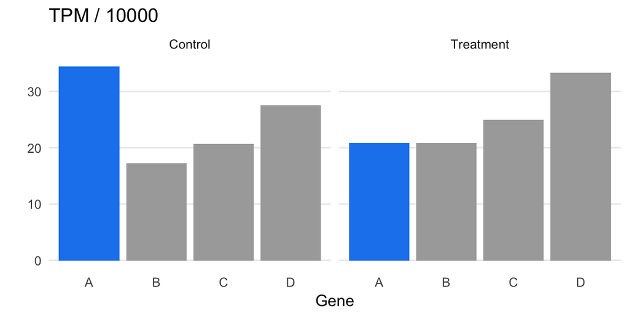

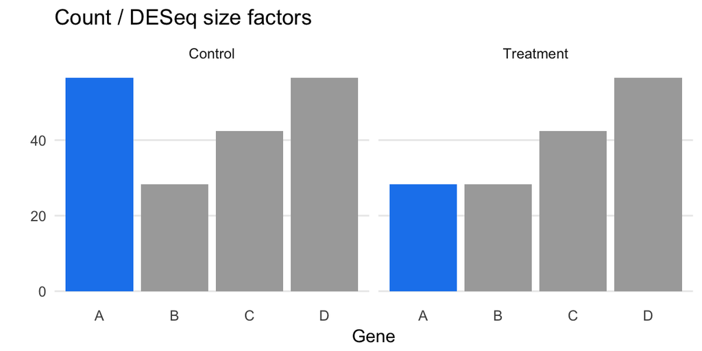

## Literature

- [What the FPKM? A review of RNA-Seq expression units](https://haroldpimentel.wordpress.com/2014/05/08/what-the-fpkm-a-review-rna-seq-expression-units/)
- [*Wagner, GP & al.*, 2012](https://paperpile.com/app/p/6bf27a5c-d26b-003b-8b28-41c62dee5051)
- [DESeq2 vignette](https://bioconductor.org/packages/devel/bioc/vignettes/DESeq2/inst/doc/DESeq2.html)
- [📜 Code for slides](https://github.com/klmr/rnaseq-norm)

## Supplementary material

### Legacy normalisation methods

- CPM = RPM = {counts/reads} per million

  $$CPM_i = x_i \cdot \frac{1}{\sum_j x_j} \cdot 10^6$$

  👎 Does not account for differences in transcript length
- RPKM = FPKM = {reads/fragments} per kilobase per million

  $$FPKM_i = \frac{x_i}{{l_\text{eff}}_i} \cdot \frac{1}{\sum_j x_j} \cdot 10^6 \cdot 10^3$$

  👎 Has different scaling factors for each RNA-seq library